# crossing-navigo-toflit-inquiry-v3

## 4.2. Test sur le port de Tonnay-Charente

```
Destinations selon navigo (en tonneaux) :
           destination  tonnage
0           Angleterre   5541.0
1  Etats de l'Empereur    482.0
2             Hollande     44.0
3             Danemark     98.0
4             Portugal     47.0
Ports pris en compte pour le bureau : Charente
Tonnage moyen des navires : 103.53333333333333
```

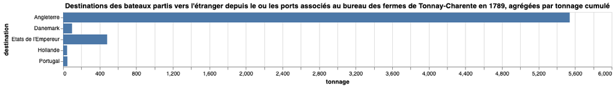

```
scan des valeurs pour le bureau des fermes de Tonnay-Charente
flux bruts toflit18 :
            partenaire        valeur
0             Portugal  4.134053e+04
1           Angleterre  4.548521e+06
2             Hollande  1.633188e+04
3  Villes hanséatiques  6.591877e+04
4  Etats de l'Empereur  4.003226e+05
5             Danemark  8.653851e+04
```

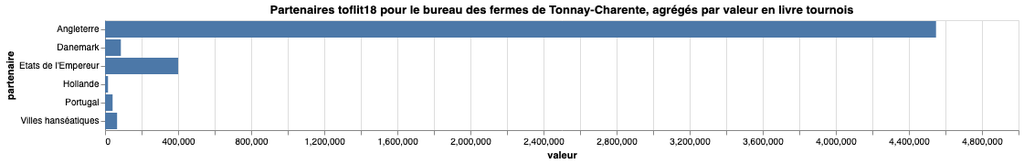

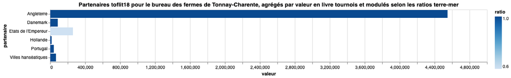

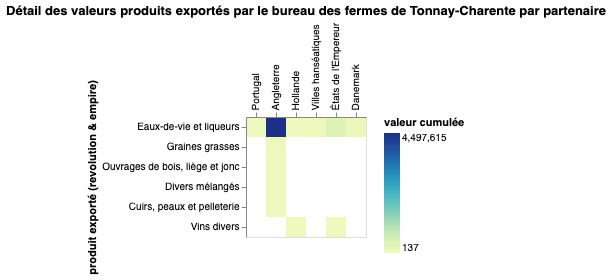

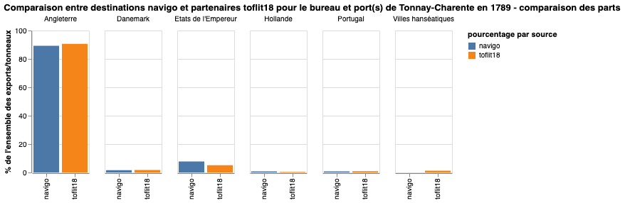

```
Correspondance résumé :
                         partner  sum_tonnage   sum_exports  price_per_barrel
0                       Danemark      33049.0  6.334500e+06        191.669945
1                     Angleterre      57563.0  3.420050e+07        594.140333
2                         Russie      14848.0  6.630000e+06        446.524784
3                        Espagne      59250.0  3.283826e+07        554.232315
4                       Hollande      78214.0  3.357150e+07        429.226225
5                       Portugal      14007.0  3.935200e+06        280.945242
6            Villes hanséatiques      68277.0  6.019470e+07        881.624852
7                          Suède      14161.0  5.053700e+06        356.874515
8          États-Unis d'Amérique      22271.0  2.050600e+06         92.074896
9                      Allemagne      28703.0  2.246440e+07        782.649897
10                        Prusse      20644.0  9.008500e+06        436.373765
11          Royaume de Sardaigne      18869.0  9.191349e+06        487.113755
12                         Gênes      38779.0  6.286100e+06        162.100621
13  Milanais, Toscane et Lucques      10210.0  1.084710e+07       1062.399608
14         États ecclésiastiques       3531.0  3.421400e+06        968.960634
15                        Naples      21383.0  5.355600e+06        250.460646
16                        Venise       1161.0  8.947000e+05        770.628768
17    Empire Ottoman et Barbarie      45285.0  2.560810e+07        565.487468
```

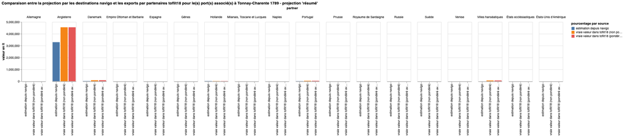

```
Total des exports en lt selon la projection 'résumé' : 3,343,005 lt
Total des exports en lt selon toflit18 : 5,158,973 lt
Total des exports en lt selon toflit18 (corrigé avec ratios terre-mer) : 5,018,691 lt
Méthode 'résumé' - rapport projection/réalité : facteur de 0.6661110006337072
```

Première analyse : les résultats de la projection sont ici plutôt proches de la réalité décrite par toflit18 : elle les sous-estime de 33%.

Hypothèse d'explication :

- l'ensemble des flux de navires concernant Angleterre, on peut supposer que les exports de Tonnay-Charentes correspondent de manière proche au commerce de la France avec la GB en général ?

## 4.3 Test sur la direction des fermes de La Rochelle et tous ses ports associés

```
Destinations selon navigo (en tonneaux) :
             destination  tonnage
0             Angleterre  12546.0
1    Etats de l'Empereur   1378.0
2                 Prusse   3696.0
3               Hollande   6639.0
4    Villes hanséatiques   4473.0
5  États-Unis d'Amérique   3038.0
6               Danemark   4915.0
7                Espagne    702.0
8               Portugal   1351.0
9                 Russie    386.0
Ports pris en compte pour le bureau : Saint Martin de Ré, Saint Gilles sur Vie, La Flotte en Ré, La Rochelle, Rochefort, Mortagne, Ars en Ré, Noirmoutier, Charente, Marennes
Tonnage moyen des navires : 129.12211221122112
```

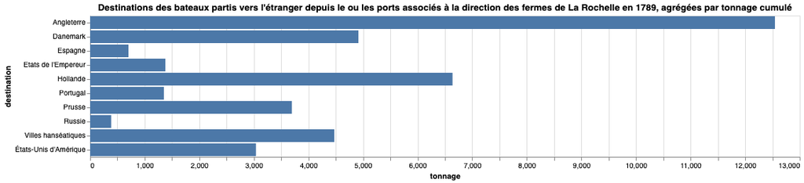

```
scan des valeurs pour la direction des fermes de La Rochelle
flux bruts toflit18 :
               partenaire        valeur
0     Monde hors colonies  5.136098e+06
1                 Espagne  3.845865e+04
2              Angleterre  4.881322e+06
3                Portugal  4.134053e+04
4                Hollande  1.615313e+05
5     Villes hanséatiques  5.422232e+05
6     Etats de l'Empereur  4.106972e+05
7                Danemark  2.882633e+05
8                  Prusse  5.127063e+04
9   États-Unis d'Amérique  5.352916e+04
10                 Russie  2.303400e+04
11                  Suède  6.009984e+03
12                Sénégal  1.591040e+06
13         Saint-Domingue  7.141800e+04
14                  Indes  3.806000e+04
Problème d'attribution du le partenaire qui n'est pas dans la table des ratios terre-mer :  Monde hors colonies
Problème d'attribution du le partenaire qui n'est pas dans la table des ratios terre-mer :  Sénégal
Problème d'attribution du le partenaire qui n'est pas dans la table des ratios terre-mer :  Indes
```

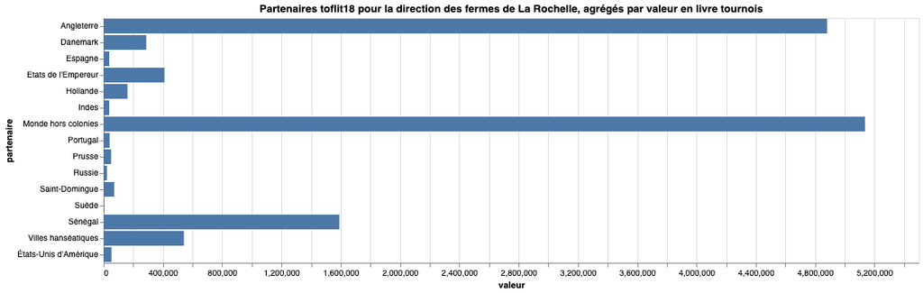

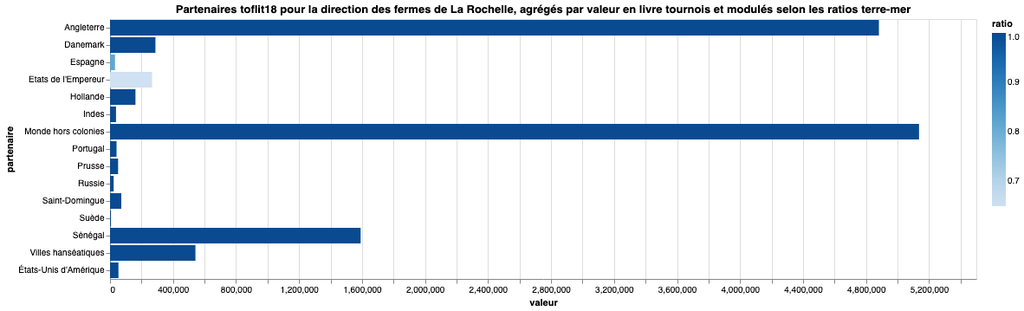

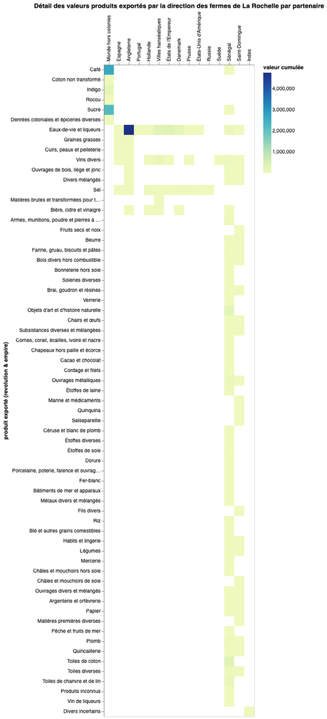

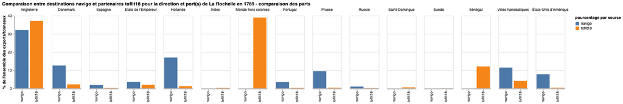

```
Correspondance résumé :
                         partner  sum_tonnage   sum_exports  price_per_barrel
0                       Danemark      33049.0  6.334500e+06        191.669945
1                     Angleterre      57563.0  3.420050e+07        594.140333
2                         Russie      14848.0  6.630000e+06        446.524784
3                        Espagne      59250.0  3.283826e+07        554.232315
4                       Hollande      78214.0  3.357150e+07        429.226225
5                       Portugal      14007.0  3.935200e+06        280.945242
6            Villes hanséatiques      68277.0  6.019470e+07        881.624852
7                          Suède      14161.0  5.053700e+06        356.874515
8          États-Unis d'Amérique      22271.0  2.050600e+06         92.074896
9                      Allemagne      28703.0  2.246440e+07        782.649897
10                        Prusse      20644.0  9.008500e+06        436.373765
11          Royaume de Sardaigne      18869.0  9.191349e+06        487.113755
12                         Gênes      38779.0  6.286100e+06        162.100621
13  Milanais, Toscane et Lucques      10210.0  1.084710e+07       1062.399608
14         États ecclésiastiques       3531.0  3.421400e+06        968.960634
15                        Naples      21383.0  5.355600e+06        250.460646
16                        Venise       1161.0  8.947000e+05        770.628768
17    Empire Ottoman et Barbarie      45285.0  2.560810e+07        565.487468
```

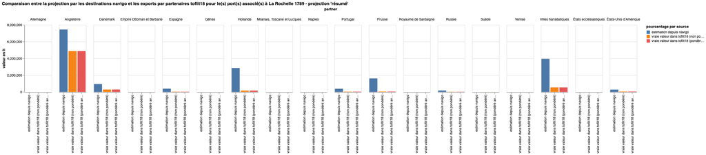

```
Total des exports en lt selon la projection 'résumé' : 18,022,830 lt
Total des exports en lt selon toflit18 : 13,334,295 lt
Total des exports en lt selon toflit18 (corrigé avec ratios terre-mer) : 13,183,366 lt
Méthode 'résumé' - rapport projection/réalité : facteur de 1.367088703751661
```

Première analyse : à l'échelle de la direction des fermes, les résultats sont assez proches de la réalité décrite par toflit18 : ils sont surestimés de 36.7%.

## 4.4. Bilan des tests sur la projection

La projection fonctionne de manière inégale suivant les corpus sur lesquels elle est testée.

Des spécificités font-elles que la projection fonctionne mieux sur certaines zones que d'autres ?

Malgré le caractère décevant et incertain de ces tests, on va néanmoins tenter de projeter le modèle sur le cas de Dunkerque en 1789.

# 5. projection sur Dunkerque 1789

On va maintenant projeter les prix par tonneau/partenaire sur les tonnages partis de Dunkerque, puis les comparer aux données toflit18 partielles dont on dispose sur le commerce colonial.

Pour le cas particulier de l'Angleterre, on va supprimer les bateaux de 12 tonneaux afin de ne pas compter les smoggleurs, pour lesquels on dispose par ailleurs d'estimations plus fiables.

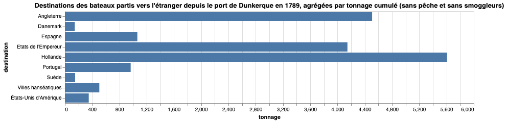

```
tonnage cumulé 17440.0
nombre de trajets :  246
nombre de trajets vers l'angleterre :  61
nombre de trajets vers l'angleterre avec cargo :  59
tonnage cumulée vers l'angleterre :  4508.0
```

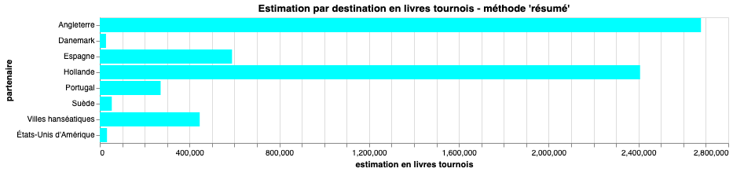

```
valeur d'export vers l'étranger estimée pour Dunkerque selon la méthode 'résumé' : 6,504,516 livres tournois
```

On compare maintenant les projections obtenues aux exports connus par toflit18, qui correspondent aux exports de produits coloniaux et aux exports vers les colonies.

```
produits navigo vers GB (tonnage cumulé) :
                  produit   valeur
0                          27744.0
1                 Briques     20.0
2              Eau-de-vie   1425.0
3                   Coton    796.0
4     Ustensiles de pêche    338.0
5   Diverses marchandises   1379.0
6                    Orge    128.0
7                   Savon    110.0
8                     Sel     14.0
9                    Lest    203.0
10                    Vin     32.0
11       Pêche à la morue    210.0
12               Planches    110.0
```

[output cut: 27 more lines]

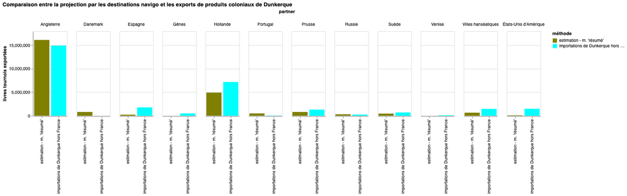

## Estimation de la valeur du smogglage

Silvia :

> pour les 10 mois de 1787, nous avons les cargaisons de 868 smogleurs. Sauf erreur (Pierre ???) ils ont exporté en contrebande 2,75 millions de livres tournois. Ce qui donnerait 3 168 livres par passage, pas de quoi faire tout un tabac....

```
Nombre de smoggleurs : 962
Estimation de la valeur du smogglage : 3047616 lt
```

## Comparaison avec les données côté anglais

Guillaume :

> Ce serait bien aussi de vérifier si les exportations légitimes de Dunkerque avec l’Angleterre (autour de 20 Millions de lt si ma mémoire est bonne) correspondent bien à ce que nous avons vu dans les données anglaises de commerce avec la Flandre.

Silvia :

> L'idée de regarder CUST est en soit excellente mais je pense qu'il faut procéder plutôt ainsi:
- utiliser les valeurs de CUST pour répérer les TOP 10 des articles les plus importants (ou TOP 20 - à voir, la liste comprend combien de lignes, et avec quelle distribution ???)
- attribuer à ce top 10 (ou 20) là, à la louche, un prix Toflit18 pur voir si notre estimation de valeur sur la base du tonnage des navires est complément foireuse.

Réponse Guillaume :

> Oui, cette méthode peut fonctionner. Mais je pense qu’il faut (au moins au début) faire plus simple. Mais il existe des indices généraux des prix des exportations s’appuyant sur le CPI (McCusker 1971 The current value of English Exports 1697-1800) qui montrent que le CPI est presque stable (de 112 à 108 entre 1697 et 1789). Comme on fait tout au doigt mouillé, je pense qu’il est mieux de faire au plus simple (au moins au début) : on regarde la valeur agrégée. Si elle entre 50% et 150% de l’estimation de Robin, on est bon. Si c’est 10% ou 200%, on est embêté (et on peut éventuellement se lancer dans des choses plus fines)

Source utilisée pour CUST : TNA, CUST 17_11 année 1789, pp 50-74 - England - import - correction en cours - https://docs.google.com/spreadsheets/d/1-yV8yIY4YFIMw9yyNKQ05Cm64O8dMf3o/edit#gid=1430909667

On calcule les exports légitimes de Dunkerque de Dunkerque vers la GB en agrégeant les valeurs des flux suivants :

- exports
- le `customs_office` contient 'dunkerque'
- le `partner_simplification` est 'Angleterre'

```
Exports légitimes/officiels de Dunkerque : 885,066 lt
```

Pour l'estimation CUST, on utilise la source suivante : TNA, CUST 17_11 année 1789, pp 50-74 - England - import - correction en cours - https://docs.google.com/spreadsheets/d/1-yV8yIY4YFIMw9yyNKQ05Cm64O8dMf3o/edit#gid=1430909667

```
Imports french flanders dans la source anglaise : 87,795 £, 1,000 shillings-£ et 448 pences-£
Imports french flanders dans la source anglaise convertis en livres tournois : 2,196,171 lt
```

## Comptes finaux

On va maintenant mettre tous les nombres ensemble pour évaluer leur fiabilité.

On va comparer les imports (connus) du port de Dunkerque avec nos projections sur les exports, ainsi que les quelques valeurs d'exports que l'on connaît :

- on calcule les imports de Dunkerque en prenant les flux toflit18 1789 avec 'Imports' et `customs_office`='Dunkerque'.
- on calcule les exports officiels/légitimes Dk->GB avec les flux toflit18 1789 pour lesquels le `customs_office` contient 'dunkerque' et le `partner_simplification` est 'Angleterre'
- on calcule le exports coloniaux en prenant les exports pour lesquels `customs_office` est 'Dunkerque' et le partenaire n'est pas la France
- on calcule les flux miroirs Dunkerque->France, on prend les flux 1789 avec `partner_simplification` == 'Dunkerque'
- on reprend le chiffre CUST construit précédemment pour avoir le point de vue anglais

```
somme imports Dunkerque : 42,931,940 lt
somme imports français depuis Dunkerque : 4,095,464 lt
somme exports coloniaux : 5,972,028 lt
somme exports selon la projection résumé : 24,947,483 lt
```

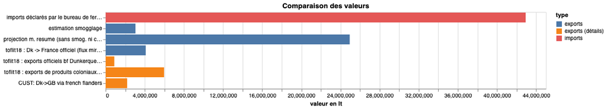

# Conclusion

Pour rappel, la méthode a consisté à :

- établir un prix par tonneau et par destination, en estimant les valeurs d'export de la France par la mer seule et les flux navigo par tonnage - pour l'année 1787
- pour les tests : d'une part sommer les flux toflit18 et les pondérer par destination en fonction des ratio terre-mer tels que décrits en 1787, d'autre part sommer les flux navigo par destination en tonnage cumulé puis les transformer en valeur via l'index des prix par tonneau par destination
- pour Dunkerque : sommer les flux navigo par destination en tonnage cumulé puis les transformer en valeur via l'index des prix par tonneau par destination

La méthode trouvée empiriquement pour calculer les prix de tonneau par partenaire semble assez fiable sur l'ensemble de la DF de La Rochelle, mais pas du tout sur d'autres corpora de test.